# Social Anxiety Analysis

## Introduction

Student Social Anxiety Survey: The data came from Carlson Hoo, a graduate student at The National University of Malaysia. The data was collected by surveying college students and asking them questions relating to situations that may trigger anxiousness. There are 12 columns and 67 rows. The main question being asked is how much of an impact does social media have on student’s anxiety, which then provides an understanding of what types of situations lead to a rise in anxiety levels. It is based on one of Hoo’s previous studies, where he wanted to find out if social media develops anxiety or helps people with anxiety. This data helps answer our first question of looking for relationships between social media and mental health. In this case, the focus is on anxiety disorders.

| Age | How many hours per day do you spend on social media? | How do you feel being the center of attention? | Working while being observed | Talking face to face with someone you don’t know very well | Expressing disagreement or disapproval to someone you don’t know very well |
| --- | --- | --- | --- | --- | --- |
| 20 or below | 4 | 4 | 4 | 3 | 3 |
| 21 - 30 | 3 | 4 | 3 | 4 | 4 |
| 31 - 40 | 3 | 3 | 3 | 3 | 4 |

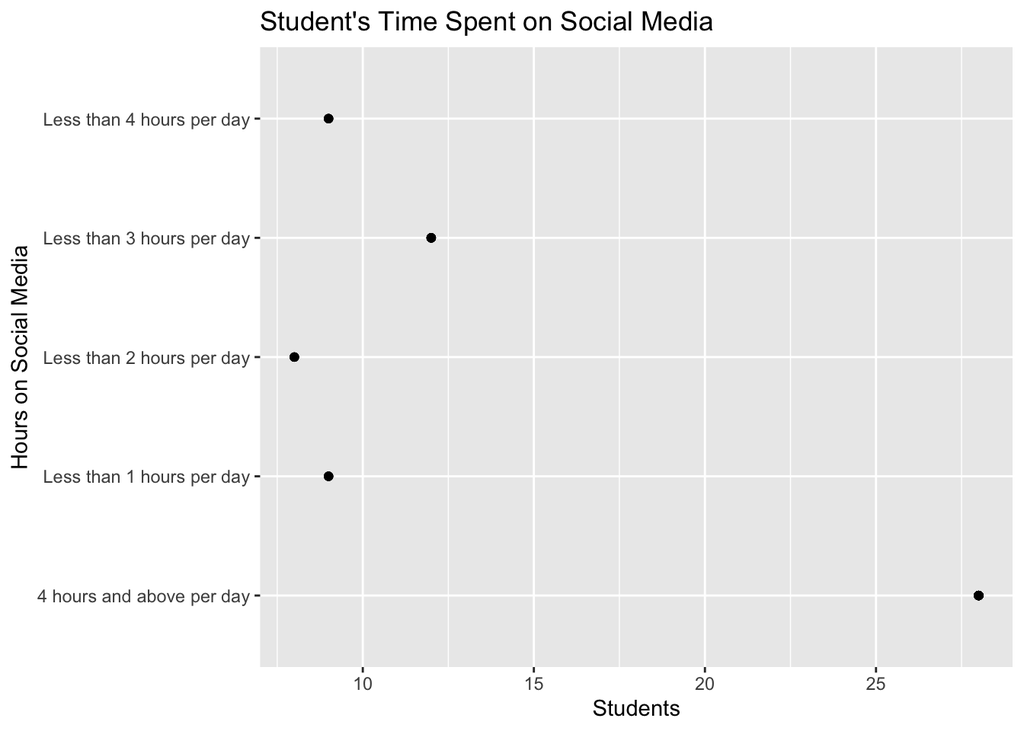

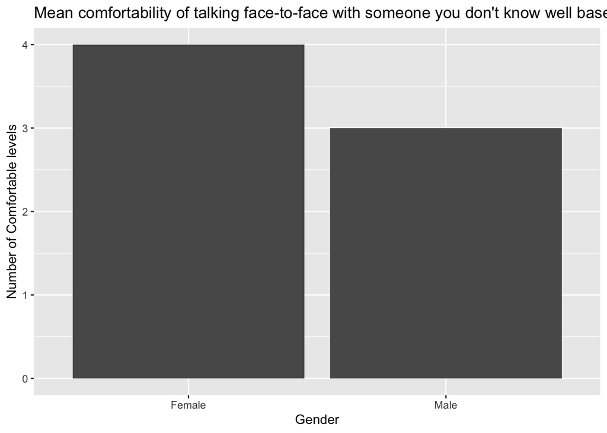

## Summary

Our summary data includes summaries of the number of people who are using social media at the lowest number of hours (given in the questionnaire), which was 9 people. In contrast, the number of people using social media at the highest number of hours (4 hours or more) was at 28. We can observe that there are a much higher portion of people who are using social media for more than 4 hours a day compared to those using it for less than an hour per day.